# Solution TP1

## Dernière mise à jour : Mon Oct 7 09:30:16 2019

## Q1. Quelle est la moyenne des votes par profession (‘job’) et par âge?

```r
## Télécharger et créer la matrice des données

library(RCurl)

### Si données locales
## u.data <- read.csv('u.data.csv', sep='|', header=T)
## u.user <- read.csv('u.user.csv', sep='|', header=T)
## u.item <- read.csv('u.item.csv', sep='|', header=T)
u.data <- read.csv(text=(getURL('http://cours.polymtl.ca/MDesmarais/log6308/Tp/20193/u.data.csv', userpwd='20113:20113')), sep='|', header=T, encoding='UTF-8')
u.user <- read.csv(text=(getURL('http://cours.polymtl.ca/MDesmarais/log6308/Tp/20193/u.user.csv', userpwd='20113:20113')), sep='|', header=T)
u.item <- read.csv(text=(getURL('http://cours.polymtl.ca/MDesmarais/log6308/Tp/20193/u.item.csv', userpwd='20113:20113')), sep='|', header=T)

library(Matrix)
m.sparse <- sparseMatrix(u.data[,1],u.data[,2],x=u.data[,3])
m <- as.matrix(m.sparse)
rownames(m.sparse) <- paste('u', 1:nrow(m.sparse), sep='')
colnames(m.sparse) <- paste('i', 1:ncol(m.sparse), sep='')

v.u <- merge(u.data, u.user, by.x='user.id', by.y='id')
head(v.u)
```

```
##   user.id item.id rating timestamp age gender        job   zip
## 1       1       1      5 874965758  24      M technician 85711
## 2       1      23      4 875072895  24      M technician 85711
## 3       1     223      5 876892918  24      M technician 85711
## 4       1     171      5 889751711  24      M technician 85711
## 5       1      16      5 878543541  24      M technician 85711
## 6       1      73      3 876892774  24      M technician 85711
```

```r
aggregate(rating ~ job, data=v.u, FUN=mean)
```

```
##              job   rating
## 1  administrator 3.635646
## 2         artist 3.653380
## 3         doctor 3.688889
## 4       educator 3.670621
## 5       engineer 3.541407
## 6  entertainment 3.441050
## 7      executive 3.349104
## 8     healthcare 2.896220
## 9      homemaker 3.301003
## 10        lawyer 3.735316
## 11     librarian 3.560781
## 12     marketing 3.485641
## 13          none 3.779134
## 14         other 3.552377
## 15    programmer 3.568260
## 16       retired 3.466750
## 17      salesman 3.582944
## 18     scientist 3.611273
## 19       student 3.515143
## 20    technician 3.532230
## 21        writer 3.375723
```

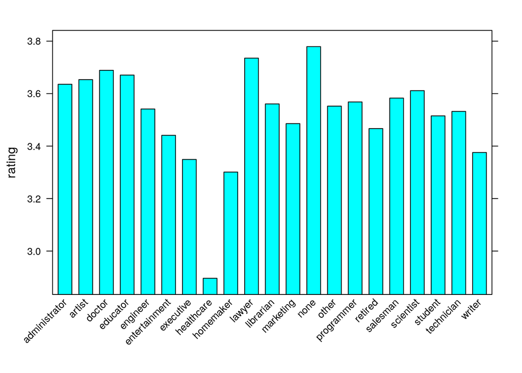

```r
library(lattice)                        # graphique
barchart(rating ~ job, data=(aggregate(rating ~ job, data=v.u, FUN=mean)), scales=list(x=list(rot=45)))
```

```r
aggregate(rating ~ job, data=v.u, FUN=length) # nombre de cas par job
```

```
##              job rating
## 1  administrator   7479
## 2         artist   2308
## 3         doctor    540
## 4       educator   9442
## 5       engineer   8175
## 6  entertainment   2095
## 7      executive   3403
## 8     healthcare   2804
## 9      homemaker    299
## 10        lawyer   1345
## 11     librarian   5273
## 12     marketing   1950
## 13          none    901
## 14         other  10663
## 15    programmer   7801
## 16       retired   1609
## 17      salesman    856
## 18     scientist   2058
## 19       student  21957
## 20    technician   3506
## 21        writer   5536
```

```r
head(aggregate(rating ~ age, data=v.u, FUN=mean))
```

```
##   age   rating
## 1   7 3.767442
## 2  10 3.387097
## 3  11 2.925926
## 4  13 3.470825
## 5  14 3.375000
## 6  15 3.264484
```

```r
(res <- aggregate(v.u$rating, by=list(age=(findInterval(v.u$age, (1:8)*10)*10)), FUN=mean)) # version par groupe d'âge
```

```
##   age        x
## 1   0 3.767442
## 2  10 3.486126
## 3  20 3.467333
## 4  30 3.554444
## 5  40 3.591772
## 6  50 3.635800
## 7  60 3.648875
## 8  70 3.649746
```

```r
## version alternative
tapply(v.u$rating, v.u$job, mean)
```

```
## administrator        artist        doctor      educator      engineer
##      3.635646      3.653380      3.688889      3.670621      3.541407
## entertainment     executive    healthcare     homemaker        lawyer
##      3.441050      3.349104      2.896220      3.301003      3.735316
##     librarian     marketing          none         other    programmer
##      3.560781      3.485641      3.779134      3.552377      3.568260
##       retired      salesman     scientist       student    technician
##      3.466750      3.582944      3.611273      3.515143      3.532230
##        writer
##      3.375723
```

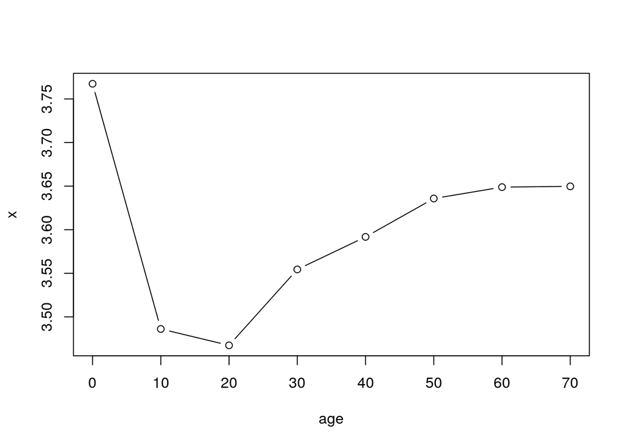

```r
plot(res, type='b')
```

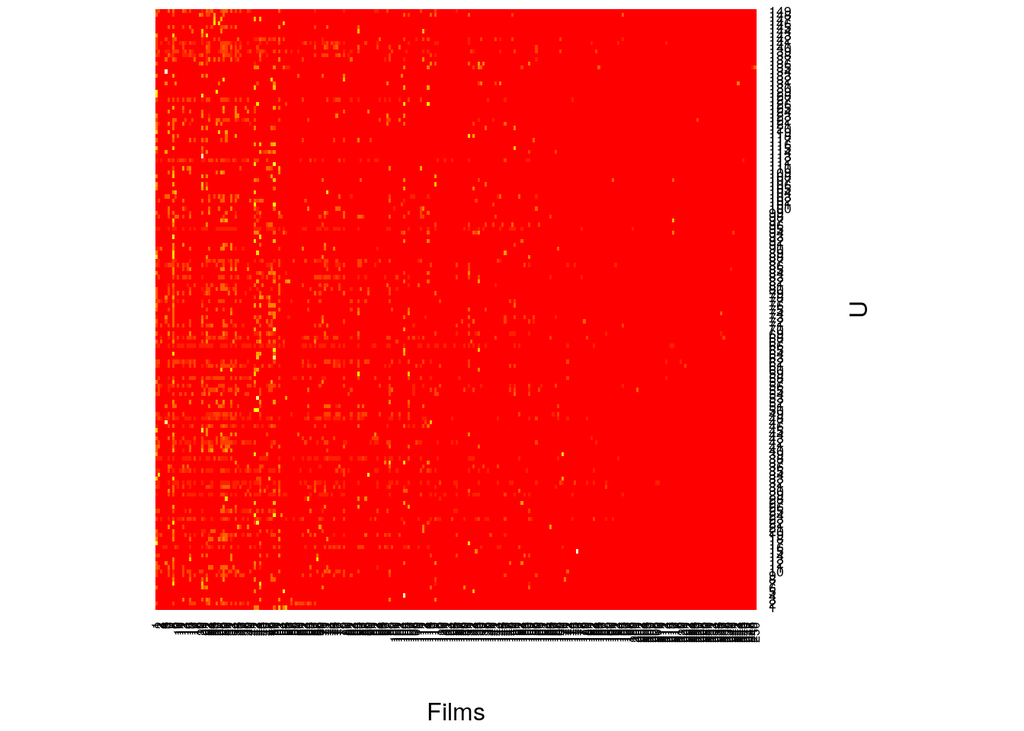

```r
## Carte de points des votes
r <- heatmap(m[sample(c(T,F),nrow(m),replace=T,prob=c(1,5)),sample(c(T,F),nrow(m),replace=T,prob=c(1,5))],Rowv=NA,Colv=NA,xlab='Films',ylab='U')
```

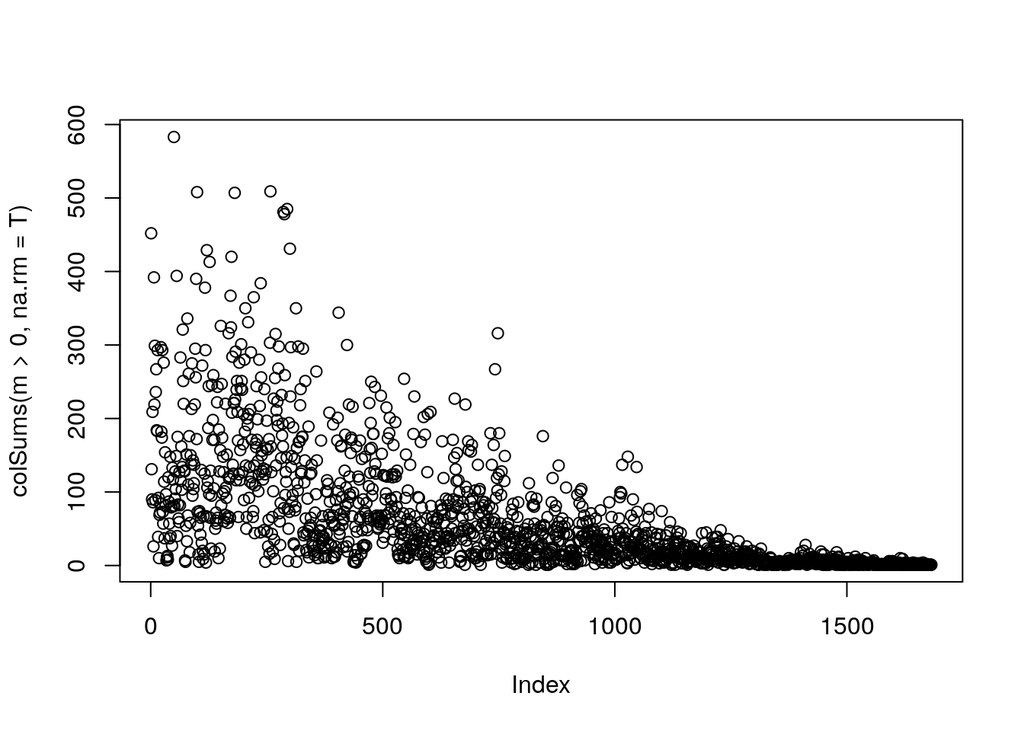

```r
plot(colSums(m>0, na.rm=T))             # tendance marquée pour les derniers films à n'avoir que peu de votes
```

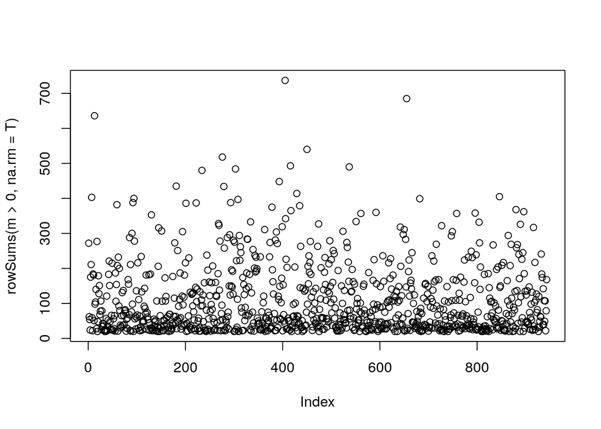

```r
plot(rowSums(m>0, na.rm=T))             # pas de tendance pour les utilisateurs
```

### Exploration du lien entre l’âge et la moyenne des votes (hors du travail à faire pour le TP1 et à titre informatif et en vue du projet)

```r
library(ggplot2)
head(u.item)
```

```
##   movie.id                                          movie.title
## 1        1                                     Toy Story (1995)
## 2        2                                     GoldenEye (1995)
## 3        3                                    Four Rooms (1995)
## 4        4                                    Get Shorty (1995)
## 5        5                                       Copycat (1995)
## 6        6 Shanghai Triad (Yao a yao yao dao waipo qiao) (1995)
##   release.date video.release.date
## 1  01-Jan-1995                 NA
## 2  01-Jan-1995                 NA
## 3  01-Jan-1995                 NA
## 4  01-Jan-1995                 NA
## 5  01-Jan-1995                 NA
## 6  01-Jan-1995                 NA
##                                                       IMDb.URL unknown
```

[output cut: 27 more lines]

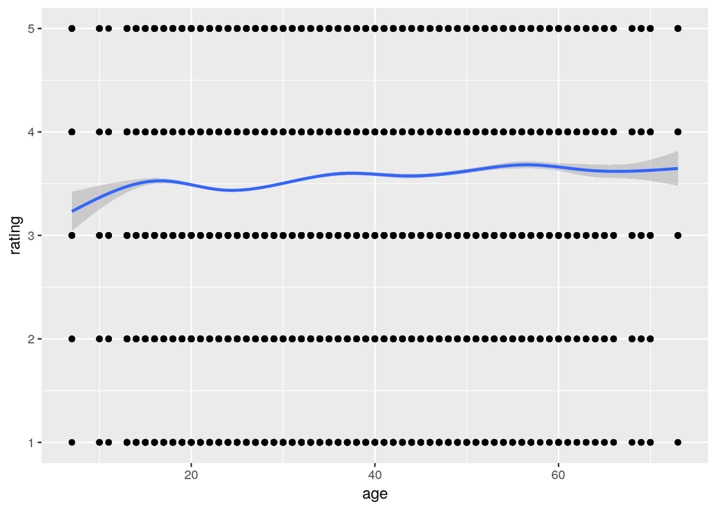

```r
qplot(age, rating, data=v.u) + geom_smooth()
```

```r
v.u2 <- merge(v.u, u.item, by.x='item.id', by.y='movie.id')
head(v.u2)
```

```
##   item.id user.id rating timestamp age gender        job   zip
## 1       1       1      5 874965758  24      M technician 85711
## 2       1     117      4 880126083  20      M    student 16125
## 3       1     429      3 882385785  27      M    student 29205
## 4       1     919      4 875289321  25      M      other 14216
## 5       1     457      4 882393244  33      F   salesman 30011
## 6       1     468      5 875280395  28      M   engineer 02341
##        movie.title release.date video.release.date
## 1 Toy Story (1995)  01-Jan-1995                 NA
## 2 Toy Story (1995)  01-Jan-1995                 NA
## 3 Toy Story (1995)  01-Jan-1995                 NA
## 4 Toy Story (1995)  01-Jan-1995                 NA
## 5 Toy Story (1995)  01-Jan-1995                 NA
## 6 Toy Story (1995)  01-Jan-1995                 NA
##                                                IMDb.URL unknown Action
```

[output cut: 20 more lines]

```r
format((as.Date('01-Jan-1999', '%d-%b-%Y')), '%Y')
```

```
## [1] "1999"
```

```r
v.u2 <- transform(v.u2, release.date=as.numeric(format(as.Date(release.date, '%d-%b-%Y'), '%Y')))
head(v.u2)
```

```
##   item.id user.id rating timestamp age gender        job   zip
## 1       1       1      5 874965758  24      M technician 85711
## 2       1     117      4 880126083  20      M    student 16125
## 3       1     429      3 882385785  27      M    student 29205
## 4       1     919      4 875289321  25      M      other 14216
## 5       1     457      4 882393244  33      F   salesman 30011
## 6       1     468      5 875280395  28      M   engineer 02341
##        movie.title release.date video.release.date
## 1 Toy Story (1995)         1995                 NA
## 2 Toy Story (1995)         1995                 NA
## 3 Toy Story (1995)         1995                 NA
## 4 Toy Story (1995)         1995                 NA
## 5 Toy Story (1995)         1995                 NA
## 6 Toy Story (1995)         1995                 NA
##                                                IMDb.URL unknown Action
```

[output cut: 20 more lines]

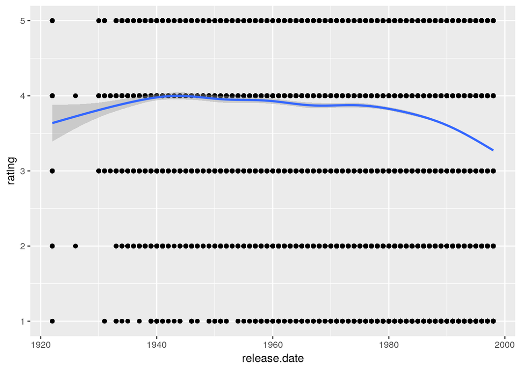

```r
qplot(release.date, rating, data=v.u2) + geom_smooth()
```

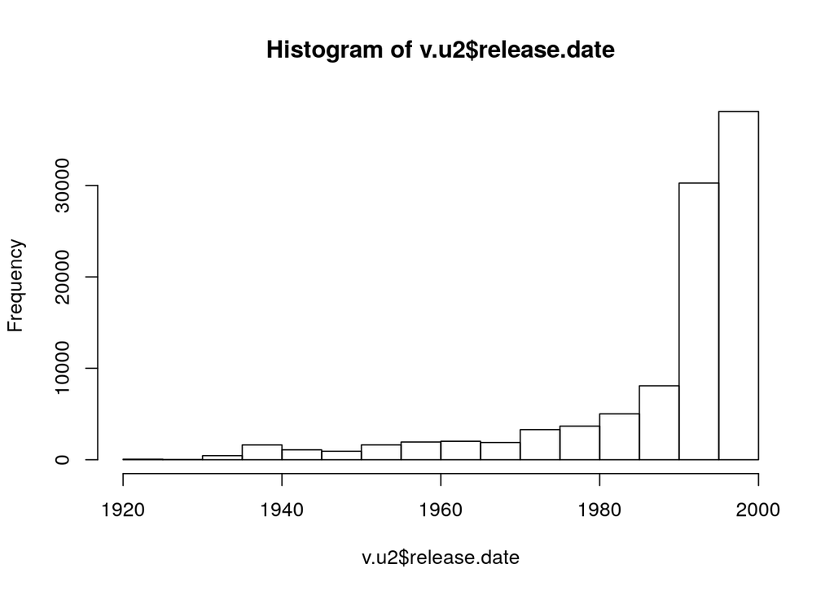

```r
hist(v.u2$release.date)
```

## Q2: Quels sont les 10 films les plus similaires à “Star Trek V: The Final Frontier (1989)” selon respectivement la mesure du cosinus et de la corrélation avec la matrice de votes.

```r
i <- grep('final frontier', as.character(u.item$movie.title), ignore.case=T)
u.item[i,]$movie.title
```

```
## [1] Star Trek V: The Final Frontier (1989)
## 1664 Levels: 'Til There Was You (1997) ... Ã\u0081 kÃ¶ldum klaka (Cold Fever) (1994)
```

```r
## Cosinus entre un vecteur v et chaque colonne dela matrice m
cosinus.vm <- function(v,m) { n <- sqrt(colSums(m^2)); (v %*% m)/(n * sqrt(sum(v^2))) }
## Cosinus des colonnes d'une matrice
cosinus.mm <- function(m) { n <- sqrt(colSums(m^2)); crossprod(m)/(n %o% n) }

# Trouve les indexes des premières 'n' valeurs maximales d'une matrice
max.nindex <- function(m, n=5) {
    i <- order(m, decreasing=TRUE)
    return(i[1:n])
}
min.nindex <- function(m, n=5) {
    i <- order(m)
    return(i[1:n])
}
```

### Selon cosinus

```r
sim.cos <- (as.vector(cosinus.vm(t(m.sparse[,i]), m.sparse)))
i.sim.cos <- max.nindex(sim.cos, n=21)
data.frame(Cos=sim.cos[i.sim.cos],Film=as.character(u.item$movie.title[i.sim.cos]), Id=i.sim.cos)
```

```
##          Cos                                          Film  Id
## 1  1.0000000        Star Trek V: The Final Frontier (1989) 450
## 2  0.6080518          Star Trek: The Motion Picture (1979) 449
## 3  0.5533220 Star Trek VI: The Undiscovered Country (1991) 227
## 4  0.5455677    Star Trek III: The Search for Spock (1984) 229
## 5  0.5144135          Star Trek IV: The Voyage Home (1986) 230
## 6  0.4702339           Star Trek: The Wrath of Khan (1982) 228
## 7  0.4540497                               Stargate (1994)  62
## 8  0.4204334                 Star Trek: Generations (1994) 380
## 9  0.3984260                             Die Hard 2 (1990) 226
## 10 0.3804155                   Escape from New York (1981) 636
## 11 0.3779706                    Conan the Barbarian (1981) 679
## 12 0.3717807             Die Hard: With a Vengeance (1995) 550
## 13 0.3711141                              True Lies (1994) 385
## 14 0.3682300                             Highlander (1986) 431
## 15 0.3676469                              Firm, The (1993)  77
## 16 0.3648952                             Waterworld (1995) 554
## 17 0.3476904                                Top Gun (1986) 161
## 18 0.3474184                         Batman Forever (1995)  29
## 19 0.3439601                               Outbreak (1995)  54
## 20 0.3401054                            Judge Dredd (1995) 373
## 21 0.3388199                               Die Hard (1988) 144
```

### Selon corrélation

```r
m <- as.matrix(m.sparse)
m0 <- m
m[m==0] <- NA
sim.cor <- cor(m[,i], m, use='pairwise.complete.obs')
i.sim.cor <- max.nindex(sim.cor, n=21)
data.frame(Cor=sim.cor[i.sim.cor],Film=as.character(u.item$movie.title[i.sim.cor]),Id=i.sim.cor )
```

```
##    Cor                                        Film  Id
## 1    1                 Operation Dumbo Drop (1995) 110
## 2    1      Star Trek V: The Final Frontier (1989) 450
## 3    1                            Wild Bill (1995) 556
## 4    1   Blue Angel, The (Blaue Engel, Der) (1930) 617
## 5    1                  So Dear to My Heart (1949) 626
## 6    1                       Paths of Glory (1957) 641
## 7    1                         The Innocent (1994) 643
## 8    1                   Kull the Conqueror (1997) 680
## 9    1                Browning Version, The (1994) 698
## 10   1                       Miami Rhapsody (1995) 700
## 11   1                         Widows' Peak (1994) 703
## 12   1                              Go Fish (1994) 733
## 13   1                    Ruling Class, The (1972) 745
## 14   1               Across the Sea of Time (1995) 757
## 15   1                        Little Odessa (1994) 782
## 16   1               Baby-Sitters Club, The (1995) 791
## 17   1                       Heaven & Earth (1993) 803
## 18   1 Two or Three Things I Know About Her (1966) 851
## 19   1                  Nosferatu a Venezia (1986) 861
## 20   1                Life Less Ordinary, A (1997) 886
## 21   1                   Great Expectations (1998) 905
```

### Quelques vérifications et explorations

```r
cosinus.vm(m0[,450],m0[,556:557])
```

```
##           i556       i557
## [1,] 0.1290169 0.06809223
```

```r
cor(m[,450],m[,556],use='pairwise.complete.obs')
```

```
## [1] 1
```

```r
table('Star Trek V'=m[,450], 'Dumbo Drop'=m[,110])
```

```
##            Dumbo Drop
## Star Trek V 1 2 3 4 5
##           1 2 0 0 0 0
##           2 0 2 0 0 0
##           3 0 0 2 0 0
##           4 0 0 0 0 0
##           5 0 0 0 0 0
```

```r
table('Star Trek V'=m[,450], 'Star Trek 1979'=m[,449])
```

```
##            Star Trek 1979
## Star Trek V 1 2 3 4 5
##           1 3 7 3 1 0
##           2 2 3 6 5 1
##           3 0 4 4 5 1
##           4 0 0 3 4 1
##           5 0 0 0 3 0
```

```r
table('Star Trek V'=m[,450], 'Wild Bill'=m[,556])
```

```
##            Wild Bill
## Star Trek V 1 2 3 4
##           1 1 0 0 0
##           2 0 0 0 0
##           3 0 0 0 0
##           4 0 0 2 0
##           5 0 0 0 0
```

On voit donc que la corrélation est sensible aux films qui ont peu de votes communs. Calculons donc la corrélation mais cette fois en prenant la variance de chaque film calculée sur l’ensemble de ses votes, tout comme le cosinus calcule la longueur sur l’ensemble des votes.

Pour cela, nous pouvons tenir utiliser le fait que la corrélation est en fait le calcul du cosinus sur les vecteurs colonnes normalisés (moyenne 0 et écart type 1).

```r
## La fonction scale normalise les colonnes.
## Cependant, il faut transformer les 0 en NA puis les remettre à 0 pour le calcul avec le cosinus.
m1 <- m0
m1[m0==0] <- NA
m1 <- scale(m1)
m1[is.na(m1)] <- 0
sim.cos.m1 <- (as.vector(cosinus.vm(t(m1[,i]), m1)))
i.sim.cos.m1 <- max.nindex(sim.cos.m1, n=21)
data.frame(Cos=sim.cos.m1[i.sim.cos.m1],Film=as.character(u.item$movie.title[i.sim.cos.m1]), Id=i.sim.cos.m1)
```

```
##          Cos                                          Film   Id
## 1  1.0000000        Star Trek V: The Final Frontier (1989)  450
## 2  0.3389857          Star Trek: The Motion Picture (1979)  449
## 3  0.3383427    Star Trek III: The Search for Spock (1984)  229
## 4  0.3060484                              Robocop 3 (1993) 1274
## 5  0.2689867                             Just Cause (1995) 1042
## 6  0.2590779                  Three Musketeers, The (1993)  399
## 7  0.2495234                 Star Trek: Generations (1994)  380
## 8  0.2434955                            Money Train (1995)  540
## 9  0.2383401                          House Party 3 (1994) 1437
## 10 0.2307516                              Mr. Magoo (1997)  901
## 11 0.2299822                                 S.F.W. (1994) 1481
## 12 0.2287831                 Across the Sea of Time (1995)  757
## 13 0.2263459 Star Trek VI: The Undiscovered Country (1991)  227
## 14 0.2241120                           Shooter, The (1995) 1027
## 15 0.2180143                    So Dear to My Heart (1949)  626
## 16 0.2154866           Geronimo: An American Legend (1993) 1004
## 17 0.2136464                             Disclosure (1994)   43
## 18 0.2080384                            Cliffhanger (1993)  576
## 19 0.2048586                     Swan Princess, The (1994) 1409
## 20 0.2018780             NeverEnding Story III, The (1994)  548
## 21 0.1946039                           The Innocent (1994)  643
```

## Q3: Utilisez une approche item-item pour calculer le vote au film “Star Trek V: The Final Frontier (1989)” des utilisateurs qui n’ont pas de vote pour celui-ci. Prenez les 20 voisins les plus rapprochés selon la distance euclidienne et utilisez les cosinus comme poids. Si aucun vote commun existe, alors la valeur prédite est fixée à NA.

```r
## Quelques vérifications
sum(m.sparse[,450]>0)     # Nombre de votes pour Star Trek V
```

```
## [1] 63
```

```r
sum((m[,450])>0, na.rm=T) # Idem avec matrice contenant NA au lieu de 0
```

```
## [1] 63
```

```r
sum(!is.na(m[,450]))      # Idem en comptant les non NA
```

```
## [1] 63
```

```r
n.voisins <- 20 + 1
votes.communs <- (colSums((m.sparse[,450] * m.sparse) > 0)) # nombre de votes communs
all(((m.sparse[,450] > 0) %*% (m.sparse > 0)) == votes.communs) # alternative
```

```
## [1] TRUE
```

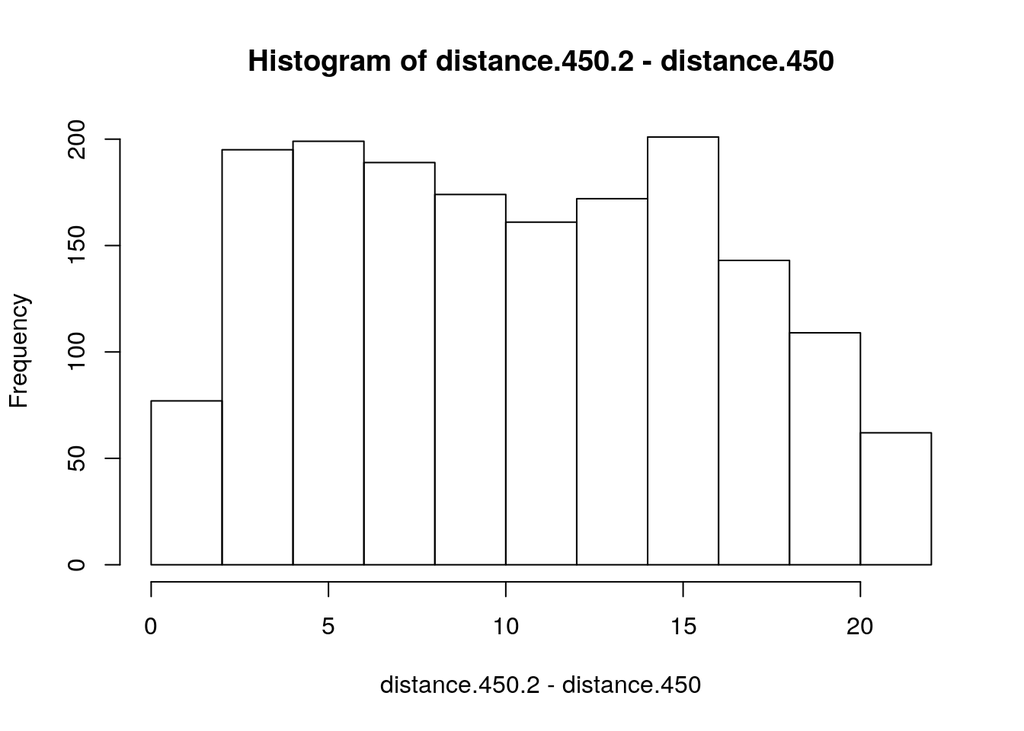

```r
## visualisation des distances avec les autres films
distance.450 <- sqrt(colSums((m.sparse[,450] - m)^2, na.rm=T))
distance.450.2 <- sqrt(colSums((m.sparse[,450] - m.sparse)^2))
hist(distance.450.2 - distance.450)
```

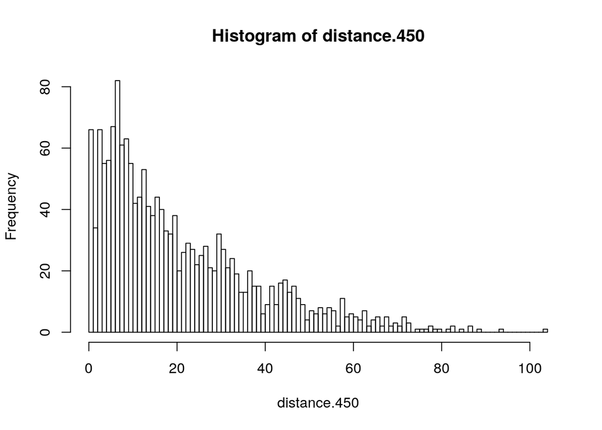

```r
hist(distance.450, breaks=100)
```

```r
distance.450[450]            # vérification
```

```
## i450
##    0
```

```r
##  Nombre de films communs
table(as.numeric(votes.communs))
```

```
##
##   0   1   2   3   4   5   6   7   8   9  10  11  12  13  14  15  16  17
## 272 275 124 119 104  66  57  64  45  42  35  39  27  18  41  31  26  24
##  18  19  20  21  22  23  24  25  26  27  28  29  30  31  32  33  34  35
##  21  21  20   8  15  14   6   9  13   7  10   9   7  10   7   5   7   5
##  36  37  38  39  40  41  42  43  44  45  46  47  48  49  50  52  54  55
##  14   8   6   4   5   1   1   3   2   5   3   5   2   4   3   1   2   2
##  56  58  59  60  63
##   1   1   1   4   1
```

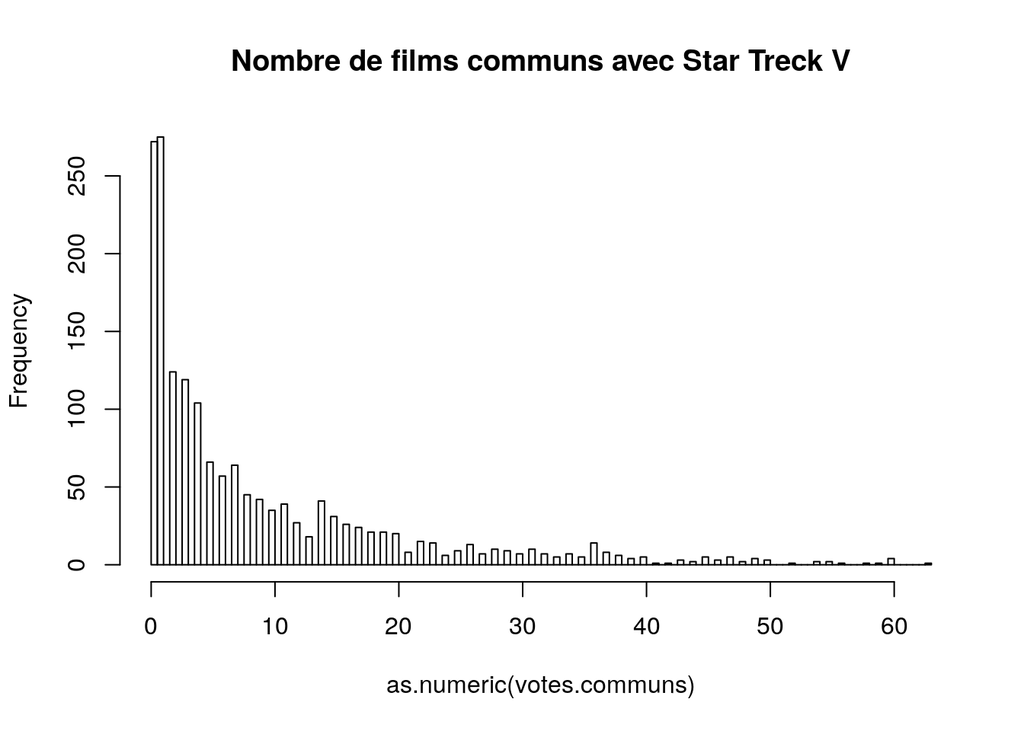

```r
hist(as.numeric(votes.communs), breaks=100, main='Nombre de films communs avec Star Treck V')
```

```r
## Calcul des voisins
(i.distance.450 <- min.nindex(distance.450, n.voisins))
```

```
##  [1]  450  857 1408 1492 1498 1510 1546 1548 1557 1559 1561 1562 1563 1564
## [15] 1565 1566 1567 1568 1569 1570 1571
```

```r
votes.communs[i.distance.450]           # problème : distances nulle si aucun vote commun
```

```
##  i450  i857 i1408 i1492 i1498 i1510 i1546 i1548 i1557 i1559 i1561 i1562
##    63     1     3     1     1     1     1     1     1     1     1     1
## i1563 i1564 i1565 i1566 i1567 i1568 i1569 i1570 i1571
##     1     1     1     1     1     1     1     1     1
```

```r
distance.450[votes.communs == 0] <- NA  # NA lorsqu'aucun vote commun
(i.distance.450 <- min.nindex(distance.450, n.voisins))
```

```
##  [1]  450  857 1408 1492 1498 1510 1546 1548 1557 1559 1561 1562 1563 1564
## [15] 1565 1566 1567 1568 1569 1570 1571
```

```r
votes.communs[i.distance.450]           # même résultat
```

```
##  i450  i857 i1408 i1492 i1498 i1510 i1546 i1548 i1557 i1559 i1561 i1562
##    63     1     3     1     1     1     1     1     1     1     1     1
## i1563 i1564 i1565 i1566 i1567 i1568 i1569 i1570 i1571
##     1     1     1     1     1     1     1     1     1
```

```r
distance.450[votes.communs < 6] <- NA   # Exigeons au moins 5 votes communs
(i.distance.450 <- min.nindex(distance.450, n.voisins))
```

```
##  [1]  450 1274  545 1145  453  669  759  446  374  574 1230  440  397 1419
## [15] 1207  590 1303  758 1407  725 1273
```

```r
votes.communs[i.distance.450]           # c'est mieux
```

```
##  i450 i1274  i545 i1145  i453  i669  i759  i446  i374  i574 i1230  i440
##    63     8     9     6    10     6     7     6     7     7     7     6
##  i397 i1419 i1207  i590 i1303  i758 i1407  i725 i1273
##     6     7    10     7     7     8    10     8     6
```

### Procédons maintenant au calcul des votes du 450

```r
## Calcul des votes selon item-item
w <- sim.cos[i.distance.450]
names(w) <- names(votes.communs[i.distance.450]) # donnons un nom aux distances
w
```

```
##       i450      i1274       i545      i1145       i453       i669
## 1.00000000 0.31809967 0.25802931 0.20075197 0.22143425 0.14488272
##       i759       i446       i374       i574      i1230       i440
## 0.23426910 0.18328121 0.17401182 0.20170175 0.16278525 0.08610027
##       i397      i1419      i1207       i590      i1303       i758
## 0.13883008 0.13959923 0.16161708 0.14957060 0.15642468 0.14995362
##      i1407       i725      i1273
## 0.22247285 0.18386809 0.13960635
```

```r
w <- w[names(w)!='i450']                       # enlevons le film à prédire pour les poids
w
```

```
##      i1274       i545      i1145       i453       i669       i759
## 0.31809967 0.25802931 0.20075197 0.22143425 0.14488272 0.23426910
##       i446       i374       i574      i1230       i440       i397
## 0.18328121 0.17401182 0.20170175 0.16278525 0.08610027 0.13883008
##      i1419      i1207       i590      i1303       i758      i1407
## 0.13959923 0.16161708 0.14957060 0.15642468 0.14995362 0.22247285
##       i725      i1273
## 0.18386809 0.13960635
```

```r
i <- i.distance.450              # index temporaire
i <- i[i!=450]                   # enlevons le film à prédire
i
```

```
##  [1] 1274  545 1145  453  669  759  446  374  574 1230  440  397 1419 1207
## [15]  590 1303  758 1407  725 1273
```

```r
m.voisins <- m[,i]               # créons une sous-matrice des voisins
head(m.voisins)
```

```
##    i1274 i545 i1145 i453 i669 i759 i446 i374 i574 i1230 i440 i397 i1419
## u1    NA   NA    NA   NA   NA   NA   NA   NA   NA    NA   NA   NA    NA
## u2    NA   NA    NA   NA   NA   NA   NA   NA   NA    NA   NA   NA    NA
## u3    NA   NA    NA   NA   NA   NA   NA   NA   NA    NA   NA   NA    NA
## u4    NA   NA    NA   NA   NA   NA   NA   NA   NA    NA   NA   NA    NA
## u5    NA   NA    NA    1   NA   NA    4    3   NA    NA    1    2    NA
## u6    NA   NA    NA   NA   NA   NA   NA   NA   NA    NA   NA   NA    NA
##    i1207 i590 i1303 i758 i1407 i725 i1273
## u1    NA   NA    NA   NA    NA   NA    NA
## u2    NA   NA    NA   NA    NA   NA    NA
## u3    NA   NA    NA   NA    NA   NA    NA
## u4    NA   NA    NA   NA    NA   NA    NA
## u5    NA   NA    NA   NA    NA   NA    NA
## u6    NA   NA    NA   NA    NA   NA    NA
```

```r
dim(m.voisins)
```

```
## [1] 943  20
```

```r
table(colSums(apply(m.voisins, 1, function(x) !is.na(x))))    # nombre de votes communs pour ces films
```

```
##
##   0   1   2   3   4   5   6   7   8  10  15
## 818  66  24  11   7   6   5   2   1   2   1
```

```r
m.centre <- t(t(m) - (colMeans(m, na.rm=T)))                  # centrons les votes
head(m.centre[,i])
```

```
##    i1274 i545 i1145    i453 i669 i759     i446      i374 i574 i1230
## u1    NA   NA    NA      NA   NA   NA       NA        NA   NA    NA
## u2    NA   NA    NA      NA   NA   NA       NA        NA   NA    NA
## u3    NA   NA    NA      NA   NA   NA       NA        NA   NA    NA
## u4    NA   NA    NA      NA   NA   NA       NA        NA   NA    NA
## u5    NA   NA    NA -0.9375   NA   NA 1.555556 0.7272727   NA    NA
## u6    NA   NA    NA      NA   NA   NA       NA        NA   NA    NA
##          i440       i397 i1419 i1207 i590 i1303 i758 i1407 i725 i1273
## u1         NA         NA    NA    NA   NA    NA   NA    NA   NA    NA
## u2         NA         NA    NA    NA   NA    NA   NA    NA   NA    NA
## u3         NA         NA    NA    NA   NA    NA   NA    NA   NA    NA
## u4         NA         NA    NA    NA   NA    NA   NA    NA   NA    NA
## u5 -0.6428571 -0.5833333    NA    NA   NA    NA   NA    NA   NA    NA
## u6         NA         NA    NA    NA   NA    NA   NA    NA   NA    NA
```

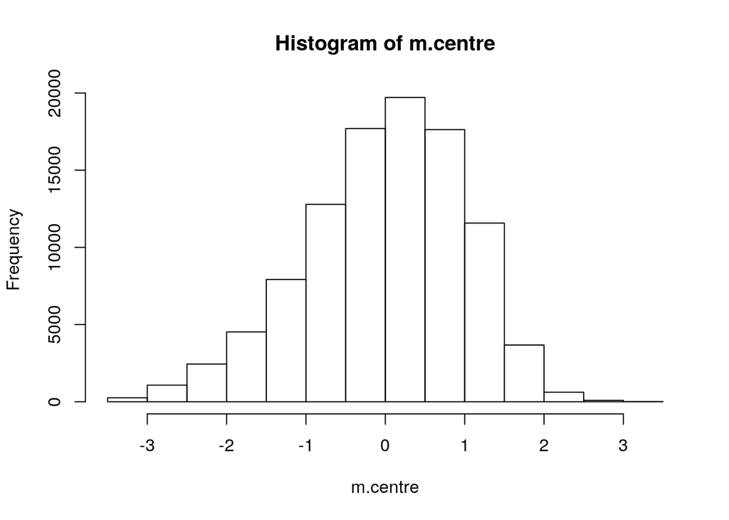

```r
hist(m.centre)                          # distribution de votes centrés
```

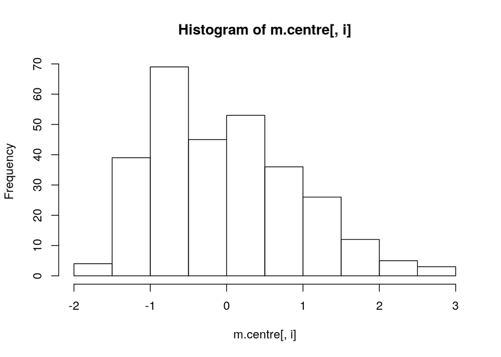

```r
hist(m.centre[,i])                      # distribution des votes pour les voisins seulement
```

```r
m.centre0 <- m.centre                   # créons une matrice avec des 0 au lieu des NA pour le calcul du cosinus
m.centre0[is.na(m.centre)] <- 0
## Application de la formule i-i
(sim.cos[i])
```

```
##  [1] 0.31809967 0.25802931 0.20075197 0.22143425 0.14488272 0.23426910
##  [7] 0.18328121 0.17401182 0.20170175 0.16278525 0.08610027 0.13883008
## [13] 0.13959923 0.16161708 0.14957060 0.15642468 0.14995362 0.22247285
## [19] 0.18386809 0.13960635
```

```r
colnames(m)[i]                # encore une vérification...
```

```
##  [1] "i1274" "i545"  "i1145" "i453"  "i669"  "i759"  "i446"  "i374"
##  [9] "i574"  "i1230" "i440"  "i397"  "i1419" "i1207" "i590"  "i1303"
## [17] "i758"  "i1407" "i725"  "i1273"
```

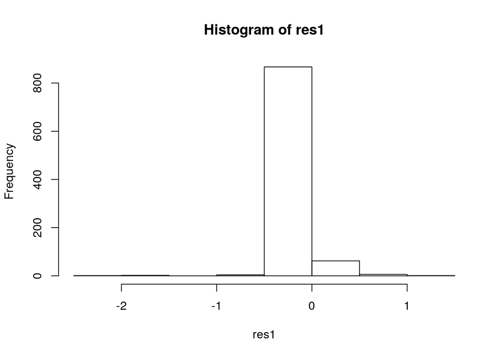

```r
## w * \sum_{i \in voisins} (Film_i - Film_i_moyen) = res1
res1 <- m.centre0[,i] %*% sim.cos[i]
hist(res1)
```

```r
sum(res1==0)                  # on aura donc une majorité d'utilisateurs sans votes communs
```

```
## [1] 819
```

```r
## Facteur de normalisation : on prend tous les cosinus pour lesquels un vote existe par utilisateur
res2 <- round(!is.na(m.centre[,i])) %*% abs(sim.cos[i])
head(res2)
```

```
##         [,1]
## u1 0.0000000
## u2 0.0000000
## u3 0.0000000
## u4 0.0000000
## u5 0.8036576
## u6 0.0000000
```

```r
## Vérification
!is.na(m.centre[1:10,i])                # valeurs non manquantes
```

```
##     i1274  i545 i1145  i453  i669  i759  i446  i374  i574 i1230  i440
## u1  FALSE FALSE FALSE FALSE FALSE FALSE FALSE FALSE FALSE FALSE FALSE
## u2  FALSE FALSE FALSE FALSE FALSE FALSE FALSE FALSE FALSE FALSE FALSE
## u3  FALSE FALSE FALSE FALSE FALSE FALSE FALSE FALSE FALSE FALSE FALSE
## u4  FALSE FALSE FALSE FALSE FALSE FALSE FALSE FALSE FALSE FALSE FALSE
## u5  FALSE FALSE FALSE  TRUE FALSE FALSE  TRUE  TRUE FALSE FALSE  TRUE
## u6  FALSE FALSE FALSE FALSE FALSE FALSE FALSE FALSE FALSE FALSE FALSE
## u7  FALSE  TRUE FALSE FALSE  TRUE FALSE  TRUE FALSE  TRUE FALSE  TRUE
## u8  FALSE FALSE FALSE FALSE FALSE FALSE FALSE FALSE FALSE FALSE FALSE
## u9  FALSE FALSE FALSE FALSE FALSE FALSE FALSE FALSE FALSE FALSE FALSE
## u10 FALSE FALSE FALSE FALSE FALSE FALSE FALSE FALSE FALSE FALSE FALSE
##      i397 i1419 i1207  i590 i1303  i758 i1407  i725 i1273
## u1  FALSE FALSE FALSE FALSE FALSE FALSE FALSE FALSE FALSE
## u2  FALSE FALSE FALSE FALSE FALSE FALSE FALSE FALSE FALSE
## u3  FALSE FALSE FALSE FALSE FALSE FALSE FALSE FALSE FALSE
## u4  FALSE FALSE FALSE FALSE FALSE FALSE FALSE FALSE FALSE
## u5   TRUE FALSE FALSE FALSE FALSE FALSE FALSE FALSE FALSE
## u6  FALSE FALSE FALSE FALSE FALSE FALSE FALSE FALSE FALSE
## u7  FALSE FALSE FALSE  TRUE FALSE FALSE FALSE FALSE FALSE
## u8  FALSE FALSE FALSE FALSE FALSE FALSE FALSE FALSE FALSE
## u9  FALSE FALSE FALSE FALSE FALSE FALSE FALSE FALSE FALSE
## u10 FALSE FALSE FALSE FALSE FALSE FALSE FALSE FALSE FALSE
```

```r
m.centre[5,i]                           # prenons la ligne 5
```

```
##      i1274       i545      i1145       i453       i669       i759
##         NA         NA         NA -0.9375000         NA         NA
##       i446       i374       i574      i1230       i440       i397
##  1.5555556  0.7272727         NA         NA -0.6428571 -0.5833333
##      i1419      i1207       i590      i1303       i758      i1407
##         NA         NA         NA         NA         NA         NA
##       i725      i1273
##         NA         NA
```

```r
!is.na(m.centre[5,i])                   # on en fait un index
```

```
## i1274  i545 i1145  i453  i669  i759  i446  i374  i574 i1230  i440  i397
## FALSE FALSE FALSE  TRUE FALSE FALSE  TRUE  TRUE FALSE FALSE  TRUE  TRUE
## i1419 i1207  i590 i1303  i758 i1407  i725 i1273
## FALSE FALSE FALSE FALSE FALSE FALSE FALSE FALSE
```

```r
sim.cos[i][!is.na(m.centre[5,i])]       # les cosinus correspondants
```

```
## [1] 0.22143425 0.18328121 0.17401182 0.08610027 0.13883008
```

```r
sum(abs(sim.cos[i])[!is.na(m.centre[5,i])])  # la somme des valeurs absolues
```

```
## [1] 0.8036576
```

```r
res2[5]                                      # le résultat selon la méthode globale ci-dessus
```

```
## [1] 0.8036576
```

```r
res2[1:5]                                    # rappel que les valeurs à 0 sont manquantes
```

```
## [1] 0.0000000 0.0000000 0.0000000 0.0000000 0.8036576
```

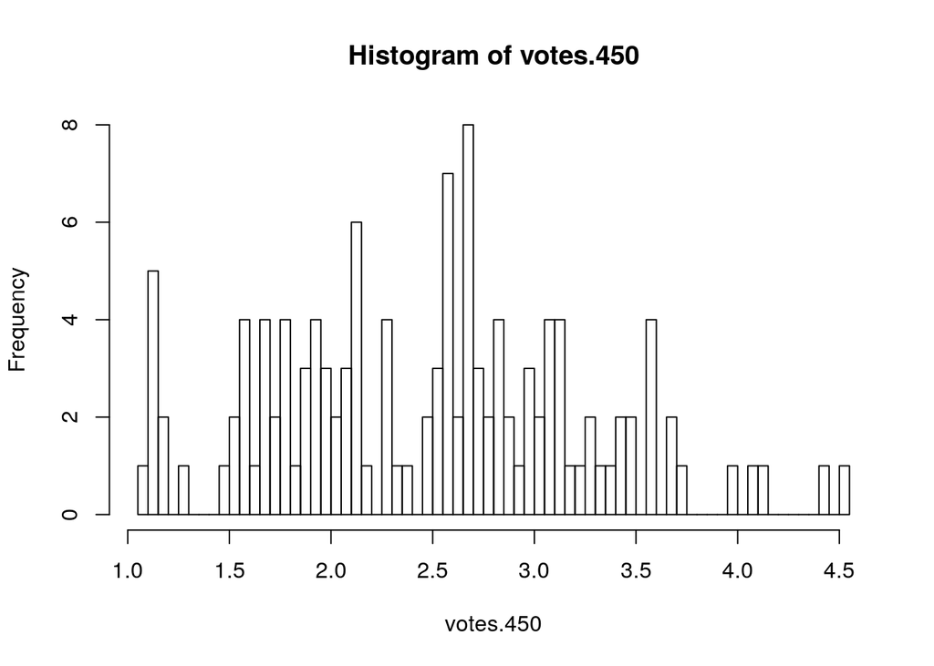

```r
## ne reste qu'à additionner les termes de l'équation complète :
## Vote_moyen_j + w_{i,j} * \sum_{i \in voisins} (Film_i - Film_i_moyen)
votes.450 <- mean(m[,450], na.rm=T) + res1 / res2
hist(votes.450, breaks=100)
```

```r
mean(m[,450], na.rm=T)
```

```
## [1] 2.396825
```

```r
mean(votes.450, na.rm=T)                # petit biais positif des prédiction qu'on pourrait vouloir corriger
```

```
## [1] 2.486442
```

## Q4. Calculez l’erreur quadratique moyenne des prédiction de l’approche item-item à la question précédente en la comparant aux valeurs observées.

```r
## Erreur absolue moyenne
i <- !is.na(votes.450) # on exclu les votes pour les voisins qui n'ont pas de votes communs
sum(i)                 # ça ne nous laisse relativement peu de prédictions
```

```
## [1] 125
```

```r
mean(abs(votes.450[i] - m[,450][i]), na.rm=T)
```

```
## [1] 0.8551958
```

```r
mean(abs(mean(m[,450], na.rm=T) - m[,450]), na.rm=T) # comparaison avec vote moyen fixe
```

```
## [1] 0.9931973
```

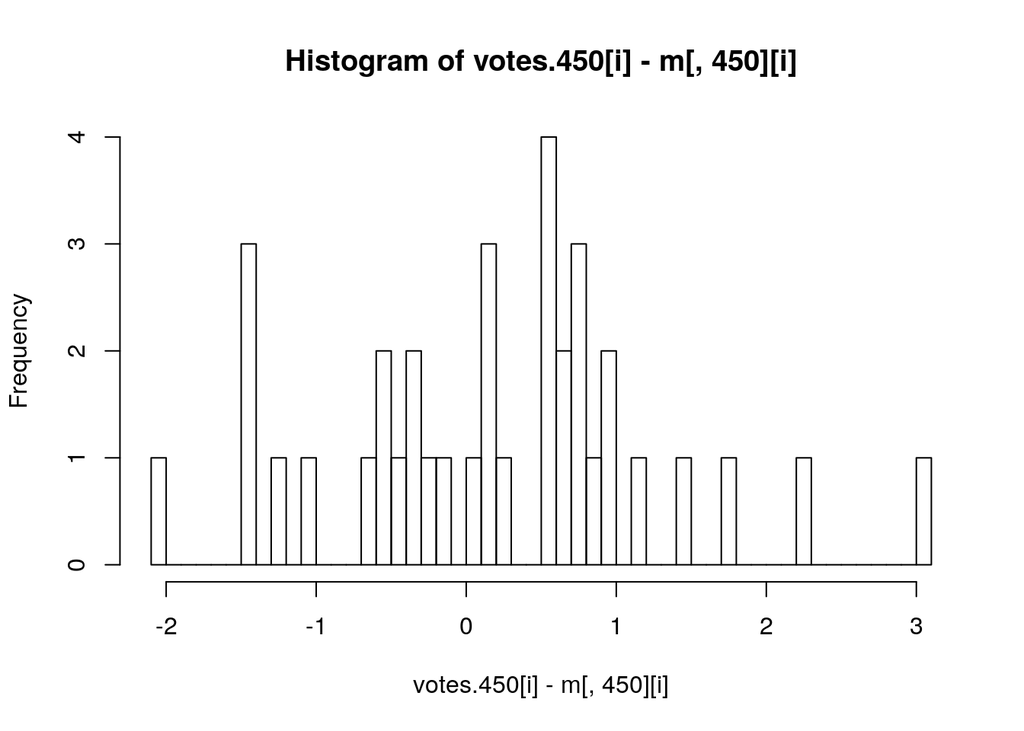

```r
hist(votes.450[i] - m[,450][i], breaks=50)           # histogramme des différences
```

```r
## Erreur quadratique moyenne
mean((votes.450[i] - m[,450][i])^2, na.rm=T)
```

```
## [1] 1.16493
```

```r
mean((mean(votes.450, na.rm=T) - m[,450][i])^2, na.rm=T) # comparaison avec vote moyen fixe
```

```
## [1] 1.241898
```

## Q5. Utilisez une approche par agglomération (clustering) pour prédire les votes et calculez l’erreur quadratique moyenne. Utilisez 5, 10 et 20 classes.

Dans cette solution, ce sont les corrélation qui sont utilisées comme distance. Il faut donc fournir à kmeans une matrice de corrélation

```r
m.agg <- m                              # remplace valeurs manquantes par moyenne pour calcul de corrélation
## ajoute aussi un petit bruit gaussien, ingrédient secret...
replaceByMean <- function(v) { v[is.na(v)] <- rnorm(sum(is.na(v)), mean(v, na.rm=T), .001); return(v); }
m.agg <- t(apply(m, 1, replaceByMean))
m.agg[1:10,1:10]
```

```
##           i1       i2       i3       i4       i5       i6       i7
## u1  5.000000 3.000000 4.000000 3.000000 3.000000 5.000000 4.000000
## u2  4.000000 3.709323 3.708981 3.711535 3.710657 3.710316 3.709861
## u3  2.797696 2.795508 2.796567 2.796195 2.795031 2.797060 2.797596
## u4  4.334076 4.333736 4.332629 4.332207 4.333619 4.333150 4.334141
## u5  4.000000 3.000000 2.873308 2.873934 2.873035 2.874107 2.874478
## u6  4.000000 3.634905 3.635435 3.633428 3.633666 3.634778 2.000000
## u7  3.966053 3.966176 3.964810 5.000000 3.966509 3.965246 5.000000
## u8  3.795149 3.796493 3.795187 3.795974 3.795065 3.796782 3.000000
## u9  4.273107 4.274124 4.272608 4.273157 4.274095 5.000000 4.000000
## u10 4.000000 4.208219 4.206473 4.000000 4.208299 4.206408 4.000000
##           i8       i9      i10
## u1  1.000000 5.000000 3.000000
## u2  3.709869 3.707958 2.000000
## u3  2.794962 2.795539 2.796444
## u4  4.333757 4.334602 4.334405
## u5  2.874537 2.874134 2.875089
## u6  4.000000 4.000000 3.634846
## u7  5.000000 5.000000 4.000000
## u8  3.795798 3.796601 3.796246
## u9  4.273441 4.272688 4.271782
## u10 4.206212 4.000000 4.205806
```

```r
any(is.na(m.agg))
```

```
## [1] FALSE
```

```r
any(is.nan(m.agg))
```

```
## [1] FALSE
```

```r
## vérification que les valeurs remplacées sont bien les moyennes des lignes
t(scale(t(m.agg), scale=F)[1:10,1:10])
```

```
##                i1            i2            i3            i4            i5
## u1   1.3897011978 -0.6102988022  3.897012e-01 -6.102988e-01 -0.6102988022
## u2   0.2903227405 -0.0003541072 -6.965074e-04  1.857485e-03  0.0009798392
## u3   0.0014121368 -0.0007759463  2.830081e-04 -8.850616e-05 -0.0012524986
## u4   0.0007080153  0.0003675411 -7.396930e-04 -1.161198e-03  0.0002508644
## u5   1.1257165345  0.1257165345 -9.754105e-04 -3.495680e-04 -0.0012483611
## u6   0.3649324369 -0.0001624848  3.670532e-04 -1.639693e-03 -0.0014012920
## u7   0.0008013685  0.0009238608 -4.422561e-04  1.034748e+00  0.0012571970
## u8  -0.0014851121 -0.0001412010 -1.446948e-03 -6.598417e-04 -0.0015687992
## u9   0.0003638150  0.0013815665 -1.343583e-04  4.142702e-04  0.0013521722
## u10 -0.2064862144  0.0017327257 -1.305557e-05 -2.064862e-01  0.0018126026
##                i6            i7            i8            i9           i10
## u1   1.389701e+00  0.3897011978 -2.6102988022  1.389701e+00 -0.6102988022
## u2   6.388821e-04  0.0001840263  0.0001913351 -1.719746e-03 -1.7096772595
## u3   7.766636e-04  0.0013123302 -0.0013216995 -7.446429e-04  0.0001605093
## u4  -2.180530e-04  0.0007729845  0.0003890241  1.233874e-03  0.0010362244
## u5  -1.766404e-04  0.0001947891  0.0002535291 -1.496872e-04  0.0008051763
## u6  -2.893839e-04 -1.6350675631  0.3649324369  3.649324e-01 -0.0002212917
## u7  -5.435893e-06  1.0347481601  1.0347481601  1.034748e+00  0.0347481601
## u8   1.480447e-04 -0.7966338134 -0.0008355393 -3.236479e-05 -0.0003878352
## u9   7.272573e-01 -0.2727427407  0.0006985306 -5.468766e-05 -0.0009609129
## u10 -7.850613e-05 -0.2064862144 -0.0002745474 -2.064862e-01 -0.0006800670
```

```r
## Calcul de la matrice de distance basée sur la corrélation (plutôt que la distance euclidienne)
m.dist <- cor(t(m.agg))                 # use='pairwise.complete.obs' serait nécessaire si nous n'avions pas le bruit gaussien
## vérification qu'il n'y a pas de valeurs manquantes
any(is.na(m.dist))
```

```
## [1] FALSE
```

```r
any(is.nan(m.dist))
```

```
## [1] FALSE
```

```r
m.km5 <- kmeans(as.dist(m.dist), 5)     # premier test avec 5 groupes
str(m.km5)  ## à noter que les centroides (centers) sont ici des corrélations car on a utilisé une matrice pour les distances
```

```
## List of 9
##  $ cluster     : Named int [1:943] 2 1 4 5 2 1 2 2 4 1 ...
##   ..- attr(*, "names")= chr [1:943] "u1" "u2" "u3" "u4" ...
##  $ centers     : num [1:5, 1:943] 0.0732 0.1008 0.036 0.015 0.0286 ...
##   ..- attr(*, "dimnames")=List of 2
##   .. ..$ : chr [1:5] "1" "2" "3" "4" ...
##   .. ..$ : chr [1:943] "u1" "u2" "u3" "u4" ...
##  $ totss       : num 2787
##  $ withinss    : num [1:5] 477 397 354 580 461
##  $ tot.withinss: num 2270
##  $ betweenss   : num 517
##  $ size        : int [1:5] 211 203 111 243 175
##  $ iter        : int 4
##  $ ifault      : int 0
##  - attr(*, "class")= chr "kmeans"
```

```r
## Instruction qui dans un premier temps applique un regroupement de moyennes basée sur les groupes (cluster) puis répête
## cette procédure sur chaque colonne.  Le résultat est l'ensemble des vecteurs centroides.
## À noter que la variable m.km$cluster contient l'appartenance de chaque ligne (individu) à un groupe
m.km5.centroids <- apply(m, 2, function(i) tapply(i, m.km5$cluster, mean, na.rm=T))

## Continuons maintenant en faisant les prédictions
str(m.km5.centroids)
```

```
##  num [1:5, 1:1682] 3.83 4.03 3.29 3.58 3.97 ...
##  - attr(*, "dimnames")=List of 2
##   ..$ : chr [1:5] "1" "2" "3" "4" ...
##   ..$ : chr [1:1682] "i1" "i2" "i3" "i4" ...
```

```r
dim(m.km5.centroids)
```

```
## [1]    5 1682
```

```r
head(m.km5.centroids[m.km5$cluster,1:5])
```

```
##         i1       i2       i3       i4       i5
## 2 4.025478 3.247059 3.090909 3.635514 3.300000
## 1 3.827869 2.833333 2.869565 3.610169 2.904762
## 4 3.583333 3.285714 2.833333 3.333333 3.714286
## 5 3.969697 3.571429 3.285714 3.352941 3.500000
## 2 4.025478 3.247059 3.090909 3.635514 3.300000
## 1 3.827869 2.833333 2.869565 3.610169 2.904762
```

```r
# Calcul de l'erreur quadratique, sans validation croisée
sqrt(mean((m.km5.centroids[m.km5$cluster,] - m)^2, na.rm=T))
```

```
## [1] 0.9455264
```

```r
## Créons une fonction pour explorer le résultat pour différents nombre de groupes
clusterPredict <- function(m, m.dist, nclust) {
    m.km <- kmeans(as.dist(m.dist), nclust)
    m.km.centroids <- apply(m, 2, function(i) tapply(i, m.km$cluster, mean, na.rm=T))
    return(sqrt(mean((m.km.centroids[m.km$cluster,] - m)^2, na.rm=T)))
}
groupements <- c(seq(2, 100, 10),c(200,500))
cbind(groupements, RMSE=sapply(groupements, function(i) clusterPredict(m, m.dist, i)))
```

```
##       groupements      RMSE
##  [1,]           2 0.9839910
##  [2,]          12 0.8993072
##  [3,]          22 0.8677129
##  [4,]          32 0.8361382
##  [5,]          42 0.8167288
##  [6,]          52 0.7938716
##  [7,]          62 0.7791501
##  [8,]          72 0.7557713
##  [9,]          82 0.7501178
## [10,]          92 0.7478741
## [11,]         200 0.6372292
## [12,]         500 0.4562970
```

Comme on pouvait s’y attendre, le résultat s’améliore continuellement avec un plus grand nombre de groupes. Ceci est dû au surapprentissage.

### Suite de Q5 pour effectuer la validation croisée qui est la Question 7

Maintenant passons à la vesion avec validation croisée.

```r
## fonction utilitaire pour vérifier si une matrice est complète
is.naornan <- function(x) (is.na(x) | is.nan(x))

## Version pour validation croisée
clusterPredictCV <- function(m, m.agg, nclust, nfolds) {
    split <- rep(1:nfolds, length.out=nrow(m))[sample(nrow(m))]
    sapply(1:nfolds, function (fold) {
        m.test.i <- (split==fold)
        m.train.i <- !m.test.i
        m.dist <- cor(t(m.agg[m.train.i,]))
        m.km <- kmeans(as.dist(m.dist), nclust)
        m.km.centroids <- apply(m[m.train.i,], 2, function(i) tapply(i, m.km$cluster, mean, na.rm=T))
    expected <- outer(rowMeans(m.km.centroids, na.rm=T), colMeans(m.km.centroids, na.rm=T), '+')/2
    expected[is.naornan(expected)] <- (outer(rowMeans(expected, na.rm=T), colMeans(expected, na.rm=T), '+')/2)[is.naornan(expected)]
    expected[is.naornan(expected)] <- mean(expected, na.rm=T)
        stopifnot(!any(is.naornan(expected)))
    m.km.centroids[is.naornan(m.km.centroids)] <- expected[is.naornan(m.km.centroids)]
        stopifnot(!any(is.naornan(m.km.centroids)))
        assign <- apply(cor(t(m.agg[m.test.i,]), t(m.km.centroids)), 1, which.max)
        return(sqrt(mean((m.km.centroids[assign,] - m[m.test.i,])^2, na.rm=T)))
    })
}

groupements <- c(2, 5, 10, 20, 50, 200)
res <- sapply(groupements, function(i) clusterPredictCV(m, m.agg, i, 5))
colnames(res) <- groupements
data.frame(groupements, RMSE=t(res))
```

```
##     groupements    RMSE.1   RMSE.2   RMSE.3   RMSE.4   RMSE.5
## 2             2 0.9963292 1.104177 1.008530 1.008066 1.028992
## 5             5 1.0215706 1.034764 1.056102 1.027252 1.054906
## 10           10 1.0264621 1.048366 1.063151 1.049062 1.053775
## 20           20 1.0875890 1.051065 1.036362 1.068710 1.091324
## 50           50 1.0981796 1.083896 1.089675 1.046419 1.051227
## 200         200 1.0970417 1.111874 1.065419 1.120509 1.093633
```

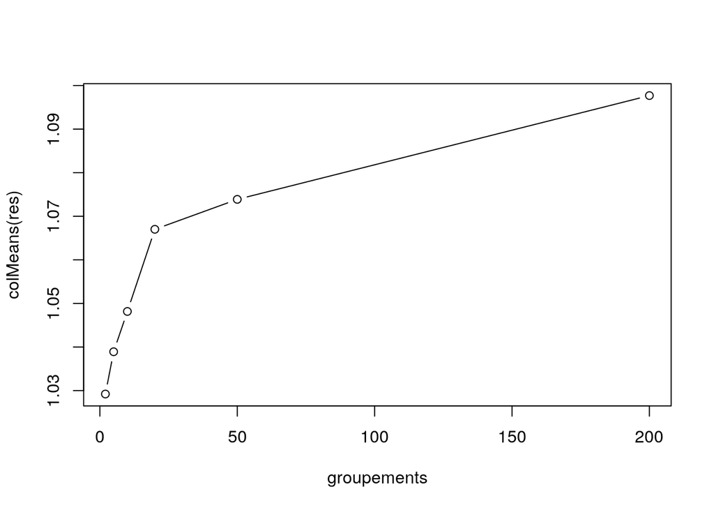

```r
plot(groupements, colMeans(res), type='b')
```

```r
## Comparons avec le résultat de la moyenne des lignes et colonnes (valeur attendue)
expected.global <- outer(rowMeans(m, na.rm=T), colMeans(m, na.rm=T), '+')/2
any(is.naornan(expected.global))
```

```
## [1] FALSE
```

```r
sqrt(mean((expected.global - m)^2, na.rm=T))
```

```
## [1] 0.966809
```

```r
## Version pour validation croisée avec distance euclidienne
clusterPredictCVEucl <- function(m, m.agg, nclust, nfolds) {
    split <- rep(1:nfolds, length.out=nrow(m))[sample(nrow(m))]
    sapply(1:nfolds, function (fold) {
        m.test.i <- (split==fold)
        m.train.i <- !m.test.i
        m.km <- kmeans(m.agg[m.train.i,], nclust)
        m.km.centroids <- apply(m[m.train.i,], 2, function(i) tapply(i, m.km$cluster, mean, na.rm=T))
    expected <- outer(rowMeans(m.km.centroids, na.rm=T), colMeans(m.km.centroids, na.rm=T), '+')/2
    expected[is.naornan(expected)] <- (outer(rowMeans(expected, na.rm=T), colMeans(expected, na.rm=T), '+')/2)[is.naornan(expected)]
    expected[is.naornan(expected)] <- mean(expected, na.rm=T)
        stopifnot(!any(is.naornan(expected)))
    m.km.centroids[is.naornan(m.km.centroids)] <- expected[is.naornan(m.km.centroids)]
        stopifnot(!any(is.naornan(m.km.centroids)))
        assign <- apply(cor(t(m.agg[m.test.i,]), t(m.km.centroids)), 1, which.max)
        return(sqrt(mean((m.km.centroids[assign,] - m[m.test.i,])^2, na.rm=T)))
    })
}

res <- sapply(groupements, function(i) clusterPredictCVEucl(m, m.agg, i, 5))
colnames(res) <- groupements
data.frame(groupements, RMSE=t(res))
```

```
##     groupements   RMSE.1   RMSE.2   RMSE.3   RMSE.4   RMSE.5
## 2             2 1.071055 1.054246 1.097751 1.056151 1.041627
## 5             5 1.122929 1.200949 1.142388 1.095800 1.160308
## 10           10 1.235214 1.250652 1.157276 1.226625 1.195669
## 20           20 1.253698 1.205583 1.173834 1.196009 1.197889
## 50           50 1.163773 1.217844 1.159634 1.127963 1.173818
## 200         200 1.180979 1.121498 1.132164 1.123808 1.125349
```

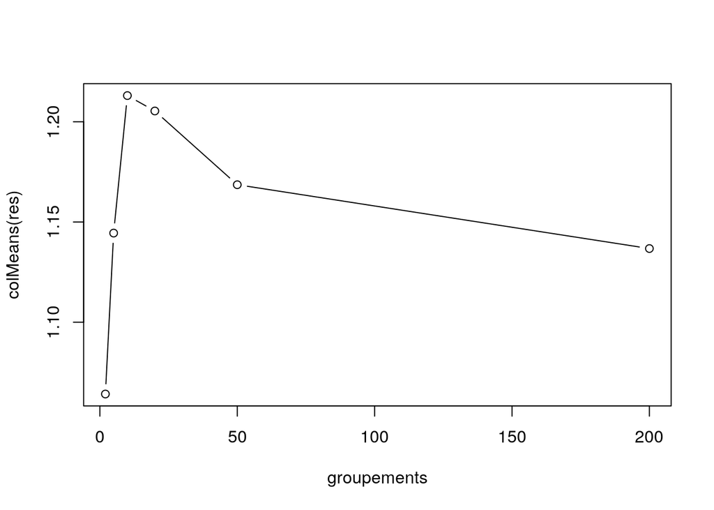

```r
plot(groupements, colMeans(res), type='b')
```

```r
0
```

```
## [1] 0
```

Comme attendu, l’erreur augmente maintenant lorsqu’on dépasse un petit nombre de groupes en utilisant la validation croisée. Il n’y a pas beaucoup de gain avec plus de 2 groupements et la prédiction est guère mieux.

## Q6. Je suis un nouvel utilisateur. Vous connaissez ma profession, mon sexe et mon âge. Développez un algorithme bayésien pour recommander 10 films sur la base de ces trois catégories.

Choisissons des facteurs pour chaque film P(E|H)/P(E|~H) avec un seuil de 4 pour aimer un film

```r
head(v.u)
```

```
##   user.id item.id rating timestamp age gender        job   zip
## 1       1       1      5 874965758  24      M technician 85711
## 2       1      23      4 875072895  24      M technician 85711
## 3       1     223      5 876892918  24      M technician 85711
## 4       1     171      5 889751711  24      M technician 85711
## 5       1      16      5 878543541  24      M technician 85711
## 6       1      73      3 876892774  24      M technician 85711
```

```r
## Dichotomization des facteurs pour utiliser l'approche Bayésienne la plus simple
v.ub <- transform(v.u, rating=sapply(v.u$rating, function(x) if(x > 3) 'like' else 'dislike'),
                       age=sapply(v.u$age, function(x) if(x>30) 'old' else 'young'))
```

On cherche à calculer (P(E|H) et P(E|~H) pour H=likes et E=job,age,gender. On peut utiliser v.ub, mais il faut que les variables soient des facteurs pour que l’aggrégation fonctionne.

```r
head(v.ub)
```

```
##   user.id item.id  rating timestamp   age gender        job   zip
## 1       1       1    like 874965758 young      M technician 85711
## 2       1      23    like 875072895 young      M technician 85711
## 3       1     223    like 876892918 young      M technician 85711
## 4       1     171    like 889751711 young      M technician 85711
## 5       1      16    like 878543541 young      M technician 85711
## 6       1      73 dislike 876892774 young      M technician 85711
```

```r
str(v.ub)
```

```
## 'data.frame':    100000 obs. of  8 variables:
##  $ user.id  : int  1 1 1 1 1 1 1 1 1 1 ...
##  $ item.id  : int  1 23 223 171 16 73 221 263 252 11 ...
##  $ rating   : chr  "like" "like" "like" "like" ...
##  $ timestamp: int  874965758 875072895 876892918 889751711 878543541 876892774 887431921 875693007 875240677 875072262 ...
##  $ age      : chr  "young" "young" "young" "young" ...
##  $ gender   : Factor w/ 2 levels "F","M": 2 2 2 2 2 2 2 2 2 2 ...
##  $ job      : Factor w/ 21 levels "administrator",..: 20 20 20 20 20 20 20 20 20 20 ...
##  $ zip      : Factor w/ 795 levels "00000","01002",..: 623 623 623 623 623 623 623 623 623 623 ...
```

```r
v.ub$age <- factor(v.ub$age)
v.ub$rating <- factor(v.ub$rating)
```

```r
v.job <- aggregate(job ~ rating + item.id, v.ub, table)
head(v.job)
```

```
##    rating item.id job.administrator job.artist job.doctor job.educator
## 1 dislike       1                 7          2          2           14
## 2    like       1                24         10          2           27
## 3 dislike       2                 2          1          0            4
## 4    like       2                 3          0          0            2
## 5 dislike       3                 2          0          0            3
## 6    like       3                 2          0          0            2
##   job.engineer job.entertainment job.executive job.healthcare
## 1           11                 5             5              3
## 2           35                 6            12              4
## 3           10                 1             1              2
## 4            6                 1             3              1
## 5            6                 2             1              2
## 6            5                 0             0              0
##   job.homemaker job.lawyer job.librarian job.marketing job.none job.other
```

[output cut: 20 more lines]

```r
## L'addressage des variables est un peu complexe...
v.job[v.job$item.id==2 & v.job$rating=='like',]$job[,'engineer']
```

```
## engineer
##        6
```

```r
v.age <- aggregate(age ~ rating + item.id, v.ub, table)
head(v.age)
```

```
##    rating item.id age.old age.young
## 1 dislike       1      58        73
## 2    like       1     148       173
## 3 dislike       2      27        53
## 4    like       2      22        29
## 5 dislike       3      15        41
## 6    like       3       4        30
```

```r
## L'addressage des variables est un peu complexe...
v.age[v.age$rating=='like' & v.age$item.id==2,]$age[,'young']
```

```
## young
##    29
```

```r
v.gender <- aggregate(gender ~ rating + item.id, v.ub, table)
head(v.gender)
```

```
##    rating item.id gender.F gender.M
## 1 dislike       1       39       92
## 2    like       1       80      241
## 3 dislike       2        9       71
## 4    like       2       10       41
## 5 dislike       3       12       44
## 6    like       3        4       30
```

```r
v.gender[v.gender$rating=='like' & v.gender$item.id==2,]$gender[,'F']
```

```
##  F
## 10
```

```r
str(v.job)
```

```
## 'data.frame':    3086 obs. of  3 variables:
##  $ rating : Factor w/ 2 levels "dislike","like": 1 2 1 2 1 2 1 2 1 2 ...
##  $ item.id: int  1 1 2 2 3 3 4 4 5 5 ...
##  $ job    : int [1:3086, 1:21] 7 24 2 3 2 2 8 8 4 2 ...
##   ..- attr(*, "dimnames")=List of 2
##   .. ..$ : NULL
##   .. ..$ : chr  "administrator" "artist" "doctor" "educator" ...
```

```r
odds.item.g.e <- function(item.id, job, gender, age) {
    ## using globals v.job=v.job, v.age=v.age, v.gender=v.gender
    ## Odds ratio for job, gender, and age
    ## À noter la correction de +1 au nominateur et dénominateur
    OR.job <- (v.job[v.job$item.id==item.id & v.job$rating=='like',]$job[,job] + 1)/
              (v.job[v.job$item.id==item.id & v.job$rating=='dislike',]$job[,job] + 1)
    OR.gender <- (v.gender[v.gender$item.id==item.id & v.gender$rating=='like',]$gender[,gender] + 1)/
              (v.gender[v.gender$item.id==item.id & v.gender$rating=='dislike',]$gender[,gender] + 1)
    OR.age <- (v.age[v.age$item.id==item.id & v.age$rating=='like',]$age[,age] + 1)/
              (v.age[v.age$item.id==item.id & v.age$rating=='dislike',]$age[,age] + 1)
    return(c(OR.job, OR.gender, OR.age))
}

odds.item.g.e(2,'engineer','F','young')
```

```
##  engineer         F     young
## 0.6363636 1.1000000 0.5555556
```

On obtient ainsi directement les valeurs pour le calcul de $\frac{P(E)/P(H)}{P(E)/P(\neg H)}$ et de $\frac{P(\neg E)/P(H)}{P(\neg E)/P(\neg H)}$ pour tous les facteurs.

Finalement, on peut appliquer la formule :

$$O(H|E_1,E_2,...) = O(H) \prod_i \frac{P(E_i)/P(H)}{P(E_i)/P(\neg H)}$$

pour chaque évidence (sexe, âge, etc.).

## Q7. Reprenez les calculs de la question 5 avec une validation croisée. Utilisez cette technique pour déterminer le nombre de classes d’agglomération.

Cette question est couverte dans la question Q5.